# PEC 4: PCA con R

José Manuel Alés Granados

## Enunciado de la práctica PEC3 de la asignatura de Álgebra Lineal de la UOC

En la televisión pública de vuestro paı́s quieren relevar al meteorólogo de cabecera para calcular y presentar la predicción meteorológica en prime time. Después de un duro proceso de selección os acaban seleccionando y hoy es el primer dı́a de trabajo.

Como especialistas en ciencia de datos, lo primero que queréis hacer es analizar perı́odos históricos temporales para observar los diferentes patrones y ver si se replican en el tiempo. Estáis interesados en conocer cuáles han sido las variables más relevantes para la predicción a lo largo del tiempo. Para realizar esta tarea, os proporcionan las observaciones diarias (a las 12 del mediodı́a) de diferentes variables relacionadas con la meteorologı́a durante un perı́odo de 3 años (2006-2008).

- *weather label* : el tiempo del dı́a (nublado: 0, lluvioso: 1, soleado: 2).
- *temperature*: temperatura (en grados centı́grados).
- *temp app*: sensación térmica (en grados centı́grados).
- *humidity*: humedad relativa (en tanto por uno [0-1]).
- *vind vel* : velocidad del viento (en kilómetros por hora).
- *vind dir* : dirección del viento (en grados).
- *visibility*: visibilidad (en kilómetros).
- *atm pres*: presión atmosférica (en milibares).

Una librerı́a que os puede ser útil para realizar la práctica es`fields` , como veréis más adelante. Recordar que debéis instalarla una sola vez y luego importarla en el código.

Antes de empezar, debéis abrir la **“Tabla resumen de la Práctica 1”** del Moodle. Allı́,encontraréis el valor de los parámetros (T , E) para poder realizar la práctica. Recordar, también, que debéis indicar los valores utilizados al inicio de la memoria, ası́ como el intento de la Tabla correspondiente (primero o segundo).

La práctica se corresponde con el *primer intento* y tiene como *T* y *E* los siguientes valores:

T = 1 E = 70

### Paso 1:

Primeramente, leer el fichero de datos correspondiente al perı́odo 2006-2008. `> data _ df <- read . csv ( ’/ home / data _ 0608. csv ’)` De la tabla resultante, guardar la primera columna (*weather label* ) al vector y y las otras columnas a la matriz de caracterı́sticas X. Responder: ¿qué dimensión tiene la matriz X?

```r
data_df <- read.csv('datasets/data_0608.csv')
y <- data_df %>%
  select(weather_label)

X <- data_df %>%
  select(-weather_label)

dimensiones_X <- dim(X)
print(paste("La Matriz X tiene ", dimensiones_X[1], " filas y ",
            dimensiones_X[2], "columnas"))
```

```
## [1] "La Matriz X tiene  1096  filas y  7 columnas"
```

la **matriz X** tiene dimensión $1096 \times 7$

### Paso 2

Antes de realizar cualquier tipo de análisis, es importante hacer una exploración estadı́stica (cuantitativa y cualitativa) de los datos. Para este propósito, observar el número de dı́as con tiempo T y calcular su temperatura media (sólo de los dı́as correspondientes a T)

```r
# Condición del intento 1
T <- 1
dias_T <- data_df %>%
  filter(weather_label == T)

# Número de días con T == 1
num_dias_T <- nrow(dias_T)
print(paste("El numero de días con tiempo T = ", T, " es ", num_dias_T))
```

```
## [1] "El numero de días con tiempo T =  1  es  164"
```

```r
# Cálculo de la temperatura de los días con T == 1
temp_media_T <- mean(dias_T$temperature)
print(paste("La temperatura media de los días con T = ", T, " es ", temp_media_T))
```

```
## [1] "La temperatura media de los días con T =  1  es  6.03658536585366"
```

### Paso 3

Para poder aplicar la descomposición en componentes principales, debéis normalizar la matriz de datos X siguiendo los criterios de la Sección 2.1 de los apuntes del módulo. Para hacerlo, debéis calcular la media y la desviación tı́pica de los datos; guardar ambas en las variables m_X y s_X, respectivamente, ya que las necesitaréis más adelante. Nombrar a la nueva matriz de datos normalizada Xs. Una vez hecho, indicar la temperatura media de todo el perı́odo 2006-2008 de los datos normalizados.

```r
# Cálculo de la media y de la desviación estándar
m_X <- colMeans(X)
s_X <- apply(X, 2, sd)

# Normalización de la matriz X
Xs <- sweep(X, 2, m_X, "-")
Xs <- sweep(Xs, 2, s_X, "/")

temperatura_media_Xs <- mean(Xs[["temperature"]])

# Mostramos los resultados
print("--Media de cada columna--")
```

```
## [1] "--Media de cada columna--"
```

```r
print(m_X)
```

```
## temperature    temp_app    humidity    wind_vel    wind_dir  visibility
##   15.484271   14.479268    0.597281   13.641122  187.662409   10.016609
##    atm_pres
##  996.252546
```

```r
print("--Desviación típica de cada columna--")
```

```
## [1] "--Desviación típica de cada columna--"
```

```r
print(s_X)
```

```
## temperature    temp_app    humidity    wind_vel    wind_dir  visibility
##   10.664018   11.910165    0.206462    7.805106  107.202710    2.757732
##    atm_pres
##  146.127179
```

```r
print(paste("La temperatura media de la matriz normalizada es ",
            temperatura_media_Xs))
```

```
## [1] "La temperatura media de la matriz normalizada es  6.38599036536197e-17"
```

### Paso 4

Para ver la relación cruzada entre las distintas variables, observar la matriz de covarianza `CXs`. Dibujarla mediante la instrucción `image.plot()` de la librerı́a `fields` y contestar: - ¿Qué variable está más asociada a la visibilidad en valor absoluto (y sin que sea ella misma)? - ¿Qué variable está menos asociada a la visibilidad en valor absoluto?

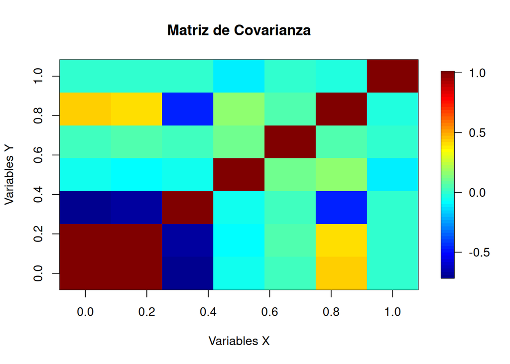

```r
# Cálculo de la matriz de covarianza
CXs <- cov(Xs)

# Impresión de la matriz de covarianza
image.plot(CXs, main = "Matriz de Covarianza", xlab = "Variables X",
           ylab = "Variables Y")
```

```r
# Obtenemos el índice de la columna visibilidad
index_visibility <- which(colnames(Xs) == "visibility")

# Guardamos el nombre de las columnas sin visibility para mostrar luego los
# nombres correctamente
colnames_ <- colnames(Xs)[-index_visibility]

# Obtenemos las asociaciones con 'visibility' excluyendo esta columna
visibility_asoc <- abs(CXs[index_visibility, -index_visibility])

# Comprobamos cuáles son las variables más y menos asociadas a la visibility
max_asoc <- which.max(visibility_asoc)
min_asoc <- which.min(visibility_asoc)

# Mostramos las variables más y menos asociadas
print(paste("La variable más asociada con la visibilidad es ", colnames_[max_asoc]))
```

```
## [1] "La variable más asociada con la visibilidad es  humidity"
```

```r
print(paste("La variable menos asociada con la visibilidad es ", colnames_[min_asoc]))
```

```
## [1] "La variable menos asociada con la visibilidad es  atm_pres"
```

### Paso 5

Seguidamente, calcular la descomposición en componentes principales de la matriz de covarianza `CXs`. **Utilizar la instrucción** `eigen` y consultar la documentación si lo necesitáis. Esta función proporciona los valores y vectores propios (componentes principales) de forma ordenada de mayor a menor varianza explicada de los datos originales. Ası́, la primera componente corresponde a la dirección de máxima varianza mientras que la última componente corresponde a la dirección de mı́nima varianza. **Dibujar** la distribución de la **varianza acumulada** (eje de ordenadas) para cada componente principal (eje de abscisas) respecto a la varianza total de los datos. Seguidamente, **indicar** el número mı́nimo de componentes necesarios P para explicar un *E%* de la varianza inicial de los datos.

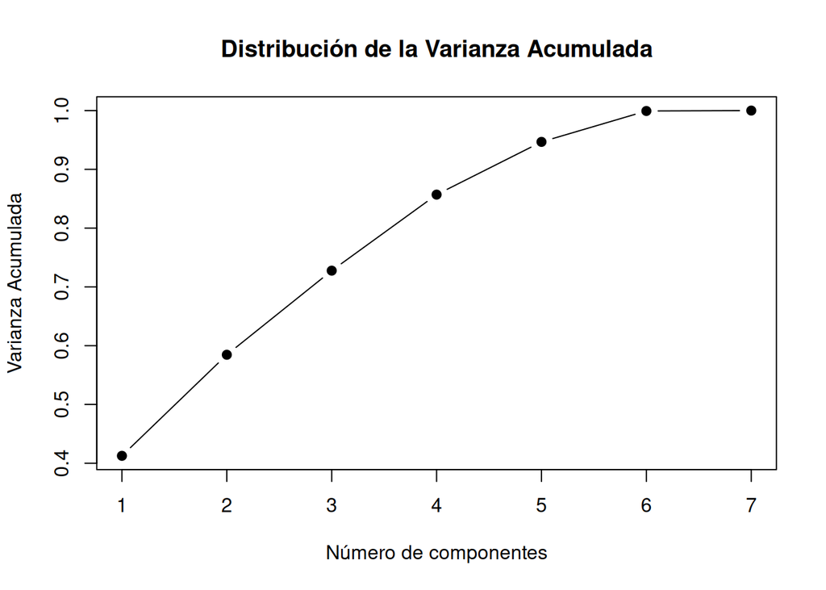

```r
# Cálculo de los VAPS y los VEPS de la matriz de covarianza
CXs_VPS <- eigen(CXs)
valores_propios <- CXs_VPS$values

# Cálculo de la varianza total
varianza_total <- sum(valores_propios)

# Cálculo de la varianza explicada por componente
varianza_explicada <- valores_propios/varianza_total

# Cálculo de la varianza acumulada
varianza_acumulada <- cumsum(varianza_explicada)

# Creación de un dataframe para graficar la varianza
varianza_df <- data.frame(
  NComponente = 1:length(varianza_acumulada),
  VarianzaAcumulada = varianza_acumulada
)

# Gráfica de la varianza acumulada
plot(varianza_acumulada, type="b", pch=19, xlab="Número de componentes",
     ylab="Varianza Acumulada", main="Distribución de la Varianza Acumulada")
```

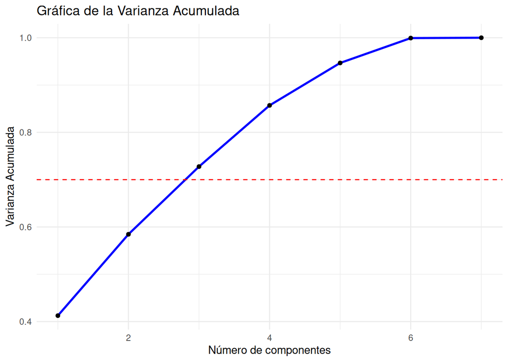

```r
ggplot(varianza_df, aes(x = NComponente, y = VarianzaAcumulada)) +
  geom_line(color="blue", linewidth=1) +
  geom_point(color="black", size=1.5) +
  geom_hline(yintercept = 0.7, linetype="dashed", color="red") +
  labs (
    title = "Gráfica de la Varianza Acumulada",
    x = "Número de componentes",
    y = "Varianza Acumulada"
  ) +
  theme_minimal()
```

### Paso 6

Con el tiempo, se os encarga un nuevo estudio, ahora durante el perı́odo 2009-2011. Como suposición inicial, considerar una distribución estacionaria de los datos, eso es, que sus propiedades estadı́sticas son constantes en el tiempo. Esto os permite utilizar la media y desviación tı́pica anteriormente calculadas ası́ como las componentes principales del perı́odo 2006-2008.

Empezar leyendo los datos del nuevo perı́odo y normalizarlos usando la media y desviación tı́pica previamente calculadas (apartado 3); guardar los datos normalizados a la matriz `Xs_test`. Una vez hecho, **contestar**: ¿cuántos dı́as de T habéis observado en este segundo perı́odo?

```r
# Carga de los datos del período 2009-2011
data2_df <- read.csv('datasets/data_0911.csv')
y2 <- data2_df %>%
  select(weather_label)

X2 <- data2_df %>%
  select(-weather_label)

# Comprobación de las dimensiones de la matriz características
dimensiones_X2 <- dim(X2)
print(paste("La Matriz X2 tiene ", dimensiones_X2[1], " filas y ",
            dimensiones_X2[2], "columnas"))
```

```
## [1] "La Matriz X2 tiene  1096  filas y  7 columnas"
```

```r
# Normalización de los datos de testeo con la media y desviación típica de los
# datos del período anterior
Xs_test <- sweep(X2, 2, m_X, "-")
Xs_test <- sweep(Xs_test, 2, s_X, "/")
```

```r
# Cuando días T = 1 hay en el segundo período
dias2_T <- data2_df %>%
  filter(weather_label==T)

# Mostramos el número de días por consola
print(paste("El número de días con T= 1 en el período 2009-2011 es ", nrow(dias2_T)))
```

```
## [1] "El número de días con T= 1 en el período 2009-2011 es  220"
```

### Paso 7

Utilizando las *P* primeras componentes principales calculadas anteriormente, proyectar los datos del perı́odo 2009-2011 (normalizados) al nuevo subespacio. Guardar dicha proyección a la variable Xproj_test. Recordar que este subespacio tiene dimensión *P* . **Responder**: ¿qué proporción (en porcentaje) de la varianza inicial de los datos explican los datos del subespacio, Xproj_test? ¿Es mayor o menor que la obtenida en el perı́odo 2006-2008?

```r
# Número de componentes calculados previamente
P <- 3

# Extración de P vectores propios
VEPS_P <- CXs_VPS$vectors[, 1:P]

# Proyección de los datos 2009-2011 normalizado al subespacio de dimensión P
Xproy_test <- as.matrix(Xs_test) %*% VEPS_P

# Proporción de la varianza inicial explicada por las P componentes
varianza_explicada1 <- sum(valores_propios[1:P])/varianza_total * 100

# Mostramos la varianza explicada
print(paste("La varianza explicada por ", P,
            " componentes de los datos 2009-2011 es, ",
            round(varianza_explicada1, 2), "%"))
```

```
## [1] "La varianza explicada por  3  componentes de los datos 2009-2011 es,  72.76 %"
```

```r
# Calculamos las varianza explicada de los datos 2006-2009 con P componentes
varianza_explicada2 <- varianza_acumulada[P]*100

print(paste("La varianza explicada por ", P,
            " componentes de los datos 2006-2009 es, ",
            round(varianza_explicada2, 2), "%"))
```

```
## [1] "La varianza explicada por  3  componentes de los datos 2006-2009 es,  72.76 %"
```

```r
# Realizamos la comprobación de la varianza explicada de ambos periodos
dif <- abs(varianza_explicada1 - varianza_explicada2)

if (varianza_explicada1 > varianza_explicada2) {
  print(paste("El periodo 2009-2011 explica un ", dif, " de varianza más"))
} else if (varianza_explicada1 < varianza_explicada2) {
  print(paste("El periodo 2006-2009 explica un ", dif, " de varianza más"))
} else {
  print(paste("Ambos periodos explican el ", round(varianza_explicada2, 2),
              "% de la varianza por lo que son iguales"))
}
```

```
## [1] "Ambos periodos explican el  72.76 % de la varianza por lo que son iguales"
```

### Paso 8

Finalmente, a partir de la proyección Xproj_test queréis recuperar los datos observados tal y como se indica a la Sección 2.5 y 2.5.1 de los apuntes del módulo. **Calcular** el error de reconstrucción y **responder**: ¿cuál es la desviación tı́pica del error de reconstrucción de la temperatura? ¿Creéis que la suposición de una distribución estacionaria de los datos es correcta?